# MSDM Culminating Experience Project (aka Capstone Project) Content and Format Template

Part of the MSDM Culminating Experience Project Guidelines

Modified

September 4, 2026

# TITLE PAGE

*(All pages in the front matters will have **1.5 inch margin** on the **left** side and 1.0 inch margins on the top, right, and bottom of a page)*

**NoteInstructions on the Title Page**

- This page should be one page long and include Project Title, appropriate description, the names of all team members, faculty advisor(s), and affiliation.
- Follow the format of [the template](https://docs.google.com/document/d/1Pv5wn9QUTmBgrY2H_9R4-MrDewLz7qaZ/edit).
- Below is how it should look like:

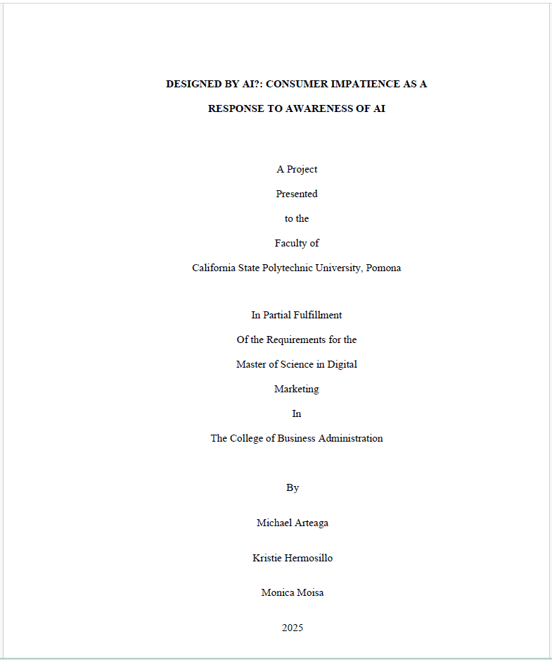

# SIGNATURE PAGE

(This page should include Project Title, the names of all team members, and faculty advisor(s)). Download [the template](https://docs.google.com/document/d/1Pv5wn9QUTmBgrY2H_9R4-MrDewLz7qaZ/edit) and just replace it with your own information. Below is how it should look like.

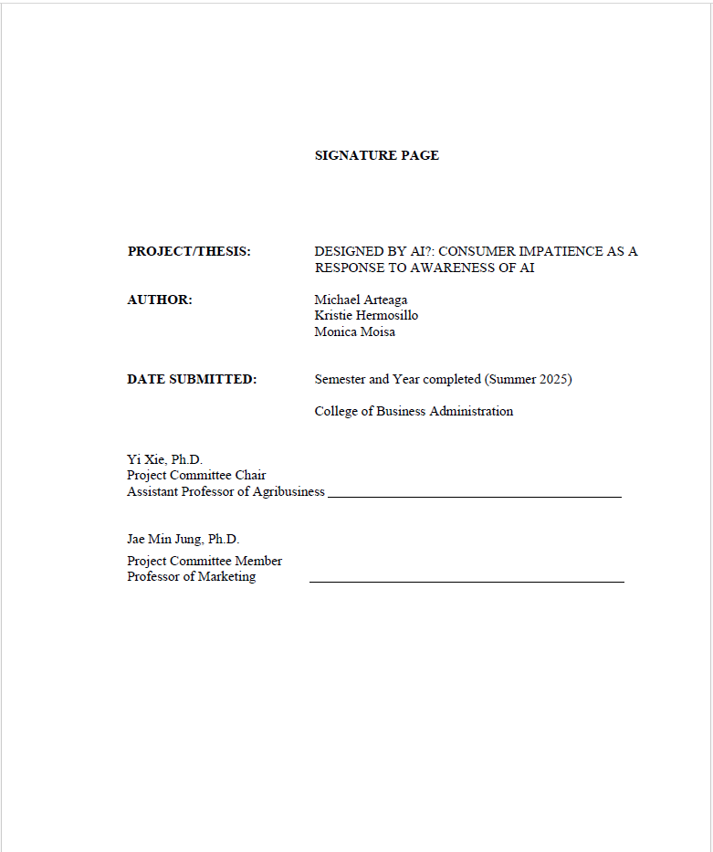

# ACKNOWLEDGMENTS PAGE

*(Optional)*

**NoteInstructions**

This is where students may acknowledge important people in their life that impacted their graduate studies, such as family members, mentors, and friends. Below is a space holder.

# ABSTRACT

*(The abstract should be no more than **250 words** including section headings and keywords.)*

**NoteInstructions for Abstract**

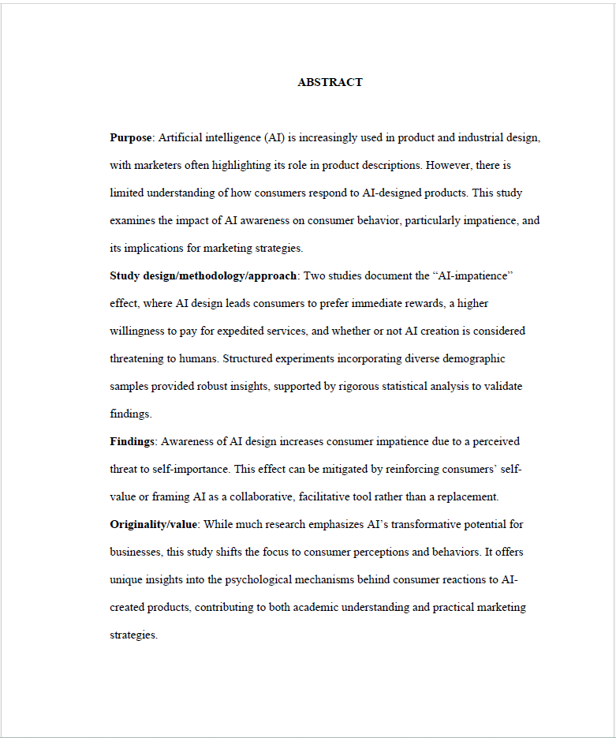

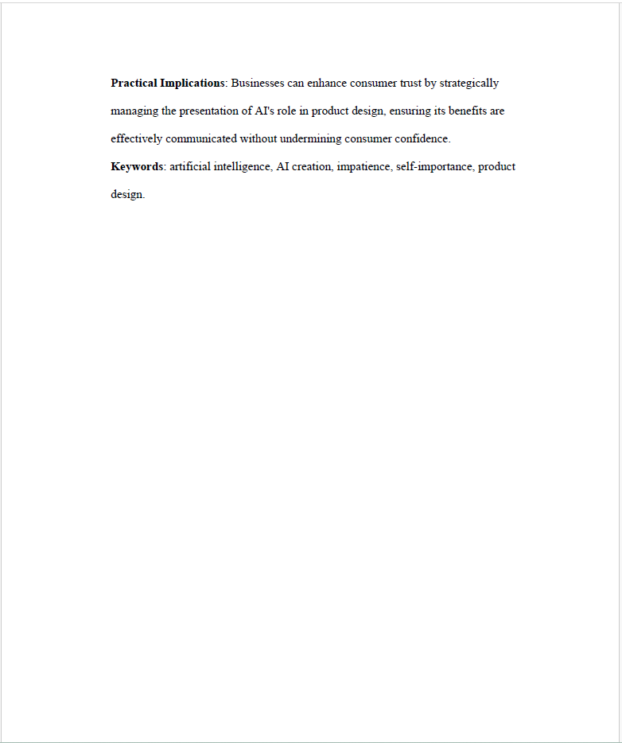

# SUMMARY OF INDIVIDUAL CONTRIBUTION

*(Each individual contribution statement should be between **75 words and 100 words**.)*

**NoteInstructions for Summary of Individual Contribution**

# TABLE OF CONTENTS

**NoteInstructions for Table of Contents**

- This section is a placeholder for the table of contents for those who use Word. If you are using Quarto, you are not required to insert a table of contents here because the table of contents will be generated automatically in the right sidebar for navigation when you submit your report in HTML format.
  - If you are using Quarto, you may submit **HTML** file rendered from Quarto, as you can generate toc on the side bar. In fact, there is no way to insert toc in the middle of sections natively in Quarto.
    - Allow up to three heading levels (h1, h2, and h3) expandable on the sidebar.
    - This document is already using the method, you can check the source code by clicking the code tools button on the top of the web page.
  - If you use **Word**, you will need to insert an automatic table of contents here using the appropriate features in Word (References > Table of Contents). The table of contents should be generated based on the headings used in the document, so make sure to use the correct heading styles for your section titles.

# 1 CHAPTER 1: INTRODUCTION

*(no more than 3 pages in double space)*

## 1.1 Background and Business Problem(s)

## 1.2 Project Objectives (PO’s)

**Note**

- Sometimes you will be presented with project objectives (PO), instead of analytics objectives (AO), in which case, you must translate the project objectives (marketing or business objectives) into analytics objectives.
- For more information on how to tell difference between AO’s and PO’s and how to convert PO’s to AO’s, follow the links.

## 1.3 Analytics Objectives

**Note**

- Each team member must have at least one AO so that they can go through the entire culminating experience process along the AO. That way, each member will have rich experience of culminating expereince as if they work on a project alone although they work as a team. Each member should focus on one analytics objective (AO) that would adress corresponding project objective (PO) to help solve the business problem(s).
- In this section, state how the AO will address the problem(s) introduced earlier. In doing so, talk about which data you will need to use for the AO and what insights you would expect to find. Please note that the analytics objectives should be relevant to the data you can collect and analyze to inform the direction of digital marketing activities. In other words, AO’s must be directly tied to data.

**TipAssessment Rubric for SLO 1: Translate a marketing problem into research questions or hypotheses that will drive the research project.**

- This section will be used to evaluate your performance on SLO 1, which is to translate a marketing problem into research questions or hypotheses that will drive the research project.
- The following rubric will be used to evaluate the quality of your model. Make sure to review this rubric carefully and use it as a guide when writing your recommendations section.

[figure not shown]

### 1.3.1 AO1. Title of AO1 (Name of Student 1)

**NoteHow to cite an article in-text**

Here is a sample of in-text citation.

Gu et al. (2024) examines how characteristics of AI-generated advertisements influence consumer acceptance through perceived eeriness and perceived intelligence and show that different ad features shape these perceptions in opposite ways, offering practical guidance for advertisers using generative AI. As consumers are ultimate judges for effectiveness of AI-generated contents (Gu et al. 2024), past research that examined consumer reactions to technology will be relevant (e.g., Reich, Kaju, and Maglio 2022; Wu and Jing Wen 2021)

**NoteCitation Syntax Explanation**

- The CSL file and citation syntax do different jobs.
- The **CSL file** controls the **formatting appearance** — punctuation, italics, author-year order, bibliography layout, etc.
- The **citation syntax** (`-@` and `[e.g., @key]`) controls the **content and structure** of what gets passed to the CSL formatter.

So the two work together, not in place of each other:

| Syntax | Purpose | Can CSL replace it? |
| --- | --- | --- |
| `-@gu2024` | Suppress author name in narrative citation | No |
| `[@gu2024]` | Standard parenthetical citation | No |
| `[e.g., @reich2022; @wu2021]` | Parenthetical with prefix | No |

### 1.3.2 AO2. Title of AO2 (Name of Student 2)

### 1.3.3 AO3. Title of AO3 (Name of Student 3)

### 1.3.4 AO4. Title of AO4 (Name of Student 4)

### 1.3.5 AO5. Title of AO5 (Name of Student 5)

## 1.4 Significance of the Topic

# 2 CHAPTER 2: BACKGROUND AND ANALYTICS OBJECTIVES

*(no specific page length guideline)*

**Tip1. Guidelines For Client Consulting Project**

- *If you are conducting a **Client Consulting Project type**, you have a company-specific analysis. Thus, follow the structure for Chapter 2 presented below.*
- For the **Client Consulting Project type**, Chapter 2 should include a comprehensive analysis of the client company and its industry, as well as an investigation of existing research frameworks/models that support the analytics objectives. The purpose of this chapter is to provide a thorough understanding of the client’s business context and to establish a strong foundation for the analytics objectives by grounding them in relevant theories and models.
- On the other hand, if you do not have a specific client company to analyze, you are completing a **Basic/Applied Academic Research Project type** where you are likely to benefit general public or the whole industry. In this case, Chapter 2 should follow the structure of the front end of an **academic research paper**. For details, refer to the 2. Guidelines for Basic/Applied Academic Research Project.

## 2.1 Client (Company) Background

### 2.1.1 Company Mission/Vision

### 2.1.2 Core Competencies

### 2.1.3 Value Propositions

### 2.1.4 Business Objectives

## 2.2 Description of the Client’s Current Marketing Program

### 2.2.1 Marketing Team and Expertise

### 2.2.2 Current Target Market

### 2.2.3 Current Positioning and Perceptual Map

*Current Perceptual Map*

### 2.2.4 Current Product/Services

### 2.2.5 Current Pricing

### 2.2.6 Current Marketing Channels

### 2.2.7 Current Integrated Marketing Communications

## 2.3 Description of the Company’s Current Digital Marketing Practices

### 2.3.1 Brand Persona

### 2.3.2 Digital Marketing Channels/Medium

#### Website and Landing Page

#### Keyword Research and SEO

#### Email Marketing

#### Social Media Posting

#### Paid Search Advertising

#### Social Media Advertising

#### Display advertising

### 2.3.3 Other digital marketing channels & tactics

#### Conversion Rate Optimization (CRO)

#### Mobile Application

#### Affiliate Marketing

#### Influencer Campaigns

### 2.3.4 Allocation of Resources to Customer-Influence Efforts

#### Demand Generation

#### Demand Harvesting

#### Loyalty Building

### 2.3.5 Analytics Infrastructure

## 2.4 Competitive Analysis

### 2.4.1 Industry Size

#### Number of Companies

#### Number of Employees

#### Annual Revenue and Key Financial Information

#### Existence of Dominant Players and Competitors

#### Market Share of Each Major Player

### 2.4.2 Industry Outlook

#### Industry Life Cycle

#### Future Sales/Profit Growth Outlook

### 2.4.3 Key Competitors and Their Digital Marketing Strategies

#### Target Market

#### Positioning

#### Website and Landing Page

#### Keyword research and SEO

#### Email Marketing Strategy

#### Social Media Posting

#### Paid Search Advertising

#### Social Media Advertising

#### Display Advertising

#### Conversion Rate Optimization (CRO)

#### Mobile Application

#### Affiliate Marketing

#### Influencer Campaigns

#### Summary Table of Comparison

## 2.5 Customer Analysis

### 2.5.1 Segments and Their Brief Justification

*Develop a profile of customers for each segment in terms of demographics, psychographics, benefits sought, behavioral patterns, etc.*

#### Segment Name A

#### Segment Name B

#### Segment Name C

#### Segment Name D

#### **Summary Table of Segments**

*In the table, each column should represent a segment, and each row should represent a customer characteristic (e.g., demographics, psychographics, benefits sought, behavioral patterns). The cell descriptions should indicate the profile of customers in each segment for each characteristic.*

### 2.5.2 Segment Analysis

*Evaluate the potential for each segment on such criteria as identifiability, actionability, substantiality, and accessibility.*

#### **Summary Table of Segment Evaluation**

*Based on the segment evaluation, identify the most attractive segment(s) to target and justify your choice.*

*In the table, each column should represent a segment, and each row should represent an evaluation criterion, plus overall attractiveness. The cell values should indicate how well each segment meets each criterion, using a consistent rating system (e.g., high, medium, low or a numerical scale).*

## 2.6 SWOT Analysis

### 2.6.1 Strengths

### 2.6.2 Weaknesses

### 2.6.3 Opportunities

### 2.6.4 Threats

### 2.6.5 **Summary: SWOT quadrants**

## 2.7 Investigation of Currently Available Research Framework/Model

**Note**

*The main purpose of this section is to gain understanding of the existing research on the topic of your project and assess if you can avoid doing redundant research that can address your analytics objectives. If indeed, there is sufficient existing research that can answer your analytics objectives, why can’t you just use the knowledge? Thus, this section is crucial for establishing a solid foundation for your research. To this end, you will be answering the four sections below by filling out the four sections. Make sure you understand what is required for each section.*

1. **Existence of Well-established Models** (2-3 pages per AO)
- Identify well-established consumer behavior theory/models/frameworks or analytical approaches relevant to the AO.
- Describe how the theory/models support the AO conceptual development in the context of solving the problem.
2. **Adequateness of Gathered Information** (a paragraph per AO)
- Assess whether the gathered information (above) is sufficient in addressing the AO and thus solving the business problem. Consider aspects such as application, accuracy, consistency, potential bias, and whether the information aligns with your research needs.
- If the gathered information is sufficient, explain how you will use the information to accomplish the AO and solve the business problem. If not, explain why the information is not sufficient and what you will do to fill the gap (e.g., additional analysis, primary research, etc.).
3. **Need for Additional Analysis** (a paragraph per AO)
- Identify if there is a need for additional analysis to address the AO in the context of the business problem. Consider if there is a need for alternative modeling techniques, methods, or data sources (e.g., primary research) to fill gaps or enhance accuracy, and how they would improve the AO.
- If you had concluded in Step 2 that the gathered information **is sufficient**, you may not need to do additional analysis. In that case, explain why the information is sufficient and how you will use it to accomplish the AO and solve the business problem.
- If you had concluded in Step 2 that the gathered information is **not sufficient**, you will likely need to do additional analysis. In that case, explain what additional analysis you will do and how it will help accomplish the AO and solve the business problem.
4. **Assessment and Affirmation of Analytics Objectives** (no more than 1 page per AO)
- In this section, you will evaluate your original AO specified in Chapter 1 in light of the information you have gathered and analyzed in the previous sections. You will specify how the AO aims to address the identified business problem(s). You will identify the analytical techniques, models or tools you plan to use. You will explain how these techniques will help accomplish the AO and why they are appropriate.

**TipAssessment Rubric for SLO 2: Evaluate known principles of consumer psychology and behaviors appropriate to address the marketing problems.**

- This section will be used to evaluate your performance on SLO 2, which is to evaluate known principles of consumer psychology and behaviors appropriate to address the marketing problems.
- The following rubric will be used to evaluate the quality of your model. Make sure to review this rubric carefully and use it as a guide when writing your recommendations section.

[figure not shown]

### 2.7.1 AO1. Title of AO1 Right Here (Name of Author Here)

*See the callout-note section above for instructions on this section. For each AO, provide the entire AO exactly as you specified in Chapter 1 so that readers do not have to refer back to the previous chapter.*

#### Existence of Well-established Models (2-3 pages per AO)

#### Adequateness of Gathered Information (a paragraph per AO)

#### Need for Additional Analysis (a paragraph per AO)

#### Assessment and Affirmation of Analytics Objectives (no more than 1 page per AO)

### 2.7.2 AO2. Title of AO2 Right Here (Name of Author Here)

#### Existence of Well-established Models (2-3 pages per AO)

#### Adequateness of Gathered Information (a paragraph per AO)

#### Need for Additional Analysis (a paragraph per AO)

#### Assessment and Affirmation of Analytics Objectives (no more than 1 page per AO)

### 2.7.3 AO3. Title of AO3 Right Here (Name of Author Here)

#### Existence of Well-established Models (2-3 pages per AO)

#### Adequateness of Gathered Information (a paragraph per AO)

#### Need for Additional Analysis (a paragraph per AO)

#### Assessment and Affirmation of Analytics Objectives (no more than 1 page per AO)

### 2.7.4 AO4. Title of AO4 Right Here (Name of Author Here)

#### Existence of Well-established Models (2-3 pages per AO)

#### Adequateness of Gathered Information (a paragraph per AO)

#### Need for Additional Analysis (a paragraph per AO)

#### Assessment and Affirmation of Analytics Objectives (no more than 1 page per AO)

### 2.7.5 AO5. Title of AO5 Right Here (Name of Author Here)

#### Existence of Well-established Models (2-3 pages per AO)

#### Adequateness of Gathered Information (a paragraph per AO)

#### Need for Additional Analysis (a paragraph per AO)

#### Assessment and Affirmation of Analytics Objectives (no more than 1 page per AO)

**Tip2. Guidelines for Basic/Applied Academic Research Project**

If your project doesn’t have a client and is intended to benefit the public or industry directly, you may find the contents for Chapter 2 described above unfit to your project. In that case, the contents provided next may be better for you. Consult with your professors.

# CHAPTER 2: For Basic/Applied Academic Research Project

*(3 - 4 pages per AO). Use the same chapter title as the client consulting project.*

**NoteBasic/Applied Academic Research Project**

If you are completing a Basic/Applied Academic Research Project type, you do not have a client company to analyze for company-specific analysis. Therefore, you cannot fill out the client-specific sections. This is why you should follow the structure of the front end of an **academic research paper**.

- For the **Basic/Applied Academic Research Project type**, Chapter 2 should follow the structure of the front end of an academic research paper, which includes an overall introduction, a literature review, theoretical development, and hypothesis development for each AO. The purpose of this chapter is to provide a comprehensive understanding of the research topic and to establish a strong foundation for the analytics objectives by grounding them in relevant theories and models.
- You will find the content and structure guidelines below is consistent with the academic papers published in many journals, such as the *Journal of Marketing*, *Journal of Consumer Research*, *Journal of the Academy of Marketing Science*, etc. You can refer to these journals for examples of how to structure and write this chapter.

## 2.8 Overall Introduction

**Note**

*Briefly introduce the business or social problem(s) the group is addressing. Summarize the purpose of the study, key theoretical concepts (constructs), analytical focus, and the expected practical and academic contributions.*

- You can write this section in a way that is similar to the introduction section of an academic research paper. Refer to journal articles for examples of how to write this section.
- This section is for the entire AO’s, so you should not write this section separately for each AO. Instead, you can write this section once at the beginning of Chapter 2, and then write the literature review, theoretical development, and hypothesis sections separately for each AO.

## 2.9 AO1. Title of AO1 Right Here (Name of Author Here)

**Note**

*Each student must write an individual section corresponding to their assigned analytics objective. These sections should be structured as follows:*

**Literature Review**

*Conduct a focused academic literature review related to the construct(s) behind the analytics objective. Include an evaluation of the quality of evidence gathered (e.g., recognize issues in terms of bias, accuracy, new findings, etc. for the information gathered) and the need for additional analysis (to support proposed research)*

- Instead of the title, “Literature review,” you can use a more specific title that reflects the content of the section, such as “User generated content” or “Consumer Response to AI-Generated Content.”

**Theoretical Development**

*This section is the continuation of the literature review. Develop a logical and theoretical argument based on the literature review that is directly relevant to the analytics objective.*

- Instead of the title, “Theoretical development,” you can use a more specific title that reflects the content of the section, such as “User generated content in the Era of AI” or “Current Status of Consumer Acceptance of AI-generated Content.”

**Hypothesis**

*Conclude the section above by identifying the clear and testable hypothesis that results from theoretical development. Each hypothesis is typically linked to a construct. In some cases, multiple AO’s may relate to the same construct (from different perspectives), or multiple AO’s may contribute to the evaluation of a single hypothesis.*

- You should not have a separate title for hypothesis. Instead, you can just write the hypothesis at the end of the theoretical development section without a title. For example, you can write, “Based on the above theoretical development, we propose the following hypothesis: [state the hypothesis here].” See journal articles for examples of how to write a hypothesis.
- You need to write a hypothesis only if your AO is related to testing a relationship between two or more constructs. If there is not a strong theoretical development that leads to a testable hypothesis, you may not need to write a hypothesis. In that case, you can call it research questions. For example, you can write, “Based on the above theoretical development, we propose the following research question: [state the research question here].” See journal articles for examples of how to write a research question.

### 2.9.1 Literature Review

### 2.9.2 Theoretical Development

### 2.9.3 Hypothesis

**Note**

*You may apply the structure of AO1 to the rest of the AO sections (AO2, AO3, AO4, and AO5). However, you are not required to follow the same structure for all AO sections. You can use different structures for different AO sections as long as you cover the three main components: literature review, theoretical development, and hypothesis/research question. The key is to ensure that each section is well-organized, logically flows, and effectively communicates the relevant information to support the analytics objective.*

## 2.10 AO2. Title of AO2 Here (Name of Author Here)

### 2.10.1 Literature Review

### 2.10.2 Theoretical Development

### 2.10.3 Hypothesis

## 2.11 AO3. Title of AO3 Here (Name of Author Here)

### 2.11.1 Literature Review

### 2.11.2 Theoretical Development

### 2.11.3 Hypothesis

## 2.12 AO4. Title of AO4 Here (Name of Author Here)

### 2.12.1 Literature Review

### 2.12.2 Theoretical Development

### 2.12.3 Hypothesis

## 2.13 AO5. Title of AO5 Here (Name of Author Here)

### 2.13.1 Literature Review

### 2.13.2 Theoretical Development

### 2.13.3 Hypothesis

# 3 CHAPTER 3: METHODS

*(6 - 10 pages)*

**NoteChapter Guidelines**

*This chapter should provide a detailed description of the methods used to accomplish the analytics objectives. The methods should be described in sufficient detail to allow for replication by other researchers. The methods should be appropriate for the analytics objectives and should be justified based on the literature review and theoretical development presented in Chapter 2.*

- For projects that need **primary data collection**,* *an instrument should be prepared* *and submitted as part of Chapter 3.
- For projects that use **secondary data**, the data source should be described in detail, including how the data was obtained and any limitations of the data.
- For projects that uses both **primary and secondary data**, both data collection methods should be described in detail.
- For more information about data collection methods, data sources, and instruments, refer to the Data Collection for the Above AO section of the main capstone project page.

## 3.1 Data and Sampling

### 3.1.1 Population

### 3.1.2 Sampling Frame

### 3.1.3 Sampling Method

## 3.2 Data Wrangling (Import, Cleaning, Transformation)

### 3.2.1 Data Collection

### 3.2.2 Data Wrangling

#### Import

#### Tidying

#### Joining the Data

### 3.2.3 Understanding the Data

#### Transform

#### Visualize

### 3.2.4 Programming

## 3.3 Sample Characteristics

#### Age

#### Gender

#### Race/ethnicity

#### Education

#### Income

#### Occupation

#### Relevant Behavioral Variables

#### Product Usage Variables.

## 3.4 Measures

**Note**

*Define the constructs in your analysis and describe how each construct will be operationalized (one item vs. multi-item). Explain what type of scale will be used (nominal, ordinal, interval, ratio), source, etc. Provide this information for each construct categorized under the following headings (IV, DV, Control). Each construct name will be another subheading. See journal articles for an idea.*

### 3.4.1 Independent Variables. (if applicable)

#### Variable Name 1

#### Variable Name 2

#### Variable Name 3

#### Variable Name 4

### 3.4.2 Dependent Variables (if applicable)

#### Variable Name 5

#### Variable Name 6

#### Variable Name 7

#### Variable Name 8

### 3.4.3 Control Variables (if applicable)

#### Variable Name 9

#### Variable Name 10

#### Variable Name 11

#### Variable Name 12

## 3.5 Analytics Methods to Employ

*(1-2 pages per AO)*

**Note**

- *In this section, provide specific data science methods, variables/features to be used, and justifications for the methods and choice of the variables/features.*
- *Provide a sufficient amount of writing (one or two paragraphs) under each AO. The word sufficiency is relativistic, depending on the objective.*
- *Your description should be able to inform readers of what the method is, why you want to use it, and what variables/features you plan to use, such that readers do not have questions.*

**TipAssessment Rubric for SLO 3: Build a model appropriate for addressing the project objectives**

- This section will in part be used to evaluate your performance on SLO 3, which is to build a model appropriate for addressing the project objectives. The specific model you build will depend on the analytics objectives you have set for your project and the data you have collected. Make sure to choose a model that is appropriate for your analytics objectives and to justify your choice of the model based on the literature review and theoretical development presented in Chapter 2.
- The following rubric will be used to evaluate the quality of your model. Make sure to review this rubric carefully and use it as a guide when writing your recommendations section.

[figure not shown]

### 3.5.1 AO1. Title of AO1 Here (Name of Author Here)

#### Method Used

#### Justification for the Method

#### Variables

### 3.5.2 AO2. Title of AO2 Here (Name of Author Here)

#### Method Used

#### Justification for the Method

#### Variables

### 3.5.3 AO3. Title of AO3 Here (Name of Author Here)

#### Method Used

#### Justification for the Method

#### Variables

### 3.5.4 AO4. Title of AO4 Here (Name of Author Here)

#### Method Used

#### Justification for the Method

#### Variables

### 3.5.5 AO5. Title of AO5 Here (Name of Author Here)

#### Method Used

#### Justification for the Method

#### Variables

# 4 CHAPTER 4: ANALYSIS/MODELING AND RESULTS

*(5-10 pages per AO)*

**NoteInstructions for Writing the Analysis/Modeling and Results Section**

- In this section, you will present data analysis andthe results of your analysis/modeling for each AO. The structure of this section may vary based on your project objectives and the nature of your analysis/modeling, but the following are common components to include for each AO.
  - *For each AO, you should have a separate subsection that includes an introduction, a description of the descriptive analytics and results, a description of the predictive analytics and results, and a summary of findings.*
- If your project analytics objectives do not involve quantitative methods, make appropriate alterations in consultation with your professors.

**TipAssessment Rubric for SLO 3: Build a model appropriate for addressing the project objectives**

- This section will in part be used to evaluate your performance on SLO 3, which is to build a model appropriate for addressing the project objectives. The specific model you build will depend on the analytics objectives you have set for your project and the data you have collected. Make sure to choose a model that is appropriate for your analytics objectives and to justify your choice of the model based on the literature review and theoretical development presented in Chapter 2.
- The following rubric will be used to evaluate the quality of your model. Make sure to review this rubric carefully and use it as a guide when writing your recommendations section.

[figure not shown]

## 4.1 AO1. Title of AO1 Here (Name of Author Here)

### 4.1.1 Introduction

### 4.1.2 Descriptive Analytics and Results

### 4.1.3 Predictive Analytics and Results

### 4.1.4 Summary Findings

## 4.2 AO2. Title of AO2 Here (Name of Author Here)

### 4.2.1 Introduction

### 4.2.2 Descriptive Analytics and Results

### 4.2.3 Predictive Analytics and Results

### 4.2.4 Summary Findings

## 4.3 AO3. Title of AO3 Here (Name of Author Here).

### 4.3.1 Introduction

### 4.3.2 Descriptive Analytics and Results

### 4.3.3 Predictive Analytics and Results

### 4.3.4 Summary Findings

## 4.4 AO4. Title of AO4 Here (Name of Author Here).

### 4.4.1 Introduction

### 4.4.2 Descriptive Analytics and Results

### 4.4.3 Predictive Analytics and Results

### 4.4.4 Summary Findings

## 4.5 AO5. Title of AO5 Here (Name of Author Here)

### 4.5.1 Introduction

### 4.5.2 Descriptive Analytics and Results

### 4.5.3 Predictive Analytics and Results

### 4.5.4 Summary Findings

# 5 CHAPTER 5: DATA-INFORMED MARKETING STRATEGY AND CONCLUSION

*(13 - 15 pages)*

**Note1. Guidelines for Client Consulting Project**

- This chapter should provide your **client** with a comprehensive discussion of the data-informed marketing strategy that you recommend based on the findings from your analysis. The specific structure of this chapter may vary based on your project goals and the nature of your recommendations, but the following are common components to include.
- If your project is **basic/applied academic research**, you may tweak the structure of this chapter to fit your project. For example, you may have a section on “Implications for Practice” where you can provide recommendations for practitioners based on your research findings, and a separate section on “Implications for Research” where you can discuss how your findings contribute to the academic literature and suggest directions for future research. Refer to journal articles to see how to structure this chapter for basic/applied academic research projects. For more details, see 2. Guidelines for Basic/Applied Academic Research section.

**TipAssessment Rubric for SLO 4a: Make data-informed recommendations on marketing strategy.**

The following rubric will be used to evaluate the quality of your recommendations and the justification for those recommendations. Make sure to review this rubric carefully and use it as a guide when writing your recommendations section.

[figure not shown]

## 5.1 AO1. Title of AO1 Here (Name of Author Here)

**Note**

The goal of this callout-note is to provide **guidance on how to structure the recommendations section for AO1.** The same structure can be applied to the rest of the AO sections (AO2, AO3, AO4, and AO5). However, you are not required to follow the same structure for all AO sections. You can use different structures for different AO sections as long as you cover the main components: summary of findings, specific recommendations, and justification for each recommendation. The key is to ensure that each section is well-organized, logically flows, and effectively communicates the relevant information to support the recommendations.

**Summary of findings from data analysis - AO1.**

- *This section includes recommendations for the company/industry and the rationale behind it. The rationale should be the insights that emerged from the analysis results. However, avoid using detailed statistics here; instead, use plain English so that even unsophisticated readers can also understand you.*
- In the next sections, provide specific recommendations based on the data analysis findings. Make sure you justify each recommendation with the insights from your analysis or/and literature.
- When writing the recommendations section, begin it with a 3rd-level heading. The heading should start with an action verb (e.g., “Allocate 30% of the advertising budget to Google Ads”).

**Do A.**

- The sample headings are provided for reference and are meant to be replaced with your own. You can have more or fewer recommendations than the sample.
- The headings should be specific to your project. The key is to make sure that the headings are actionable and directly tied to the insights from your analysis.
- After this heading, start the paragraph in the same line. The writing should focus on justifying the recommendation. Use the research findings that support the recommendation.

**Implement B.**

*The same guidelines for Do A apply to Implement B. The only difference is that the heading should start with an action verb that indicates implementation (e.g., “Implement a retargeting campaign on Facebook”).*

**Change C to D.**

*The same guidelines for Do A apply to Change C to D. The only difference is that the heading should start with an action verb that indicates change (e.g., “Change the target audience from millennials to Gen Z”).*

### 5.1.1 Summary of Findings from Data Analysis - AO1

### 5.1.2 Do A

### 5.1.3 Implement B

### 5.1.4 Change C to D

**Note**

Using the same structure as AO1, provide recommendations for the rest of the AO sections (AO2, AO3, AO4, and AO5). Follow the same structure for all AO sections, but adapt the content to reflect the unique insights and recommendations for each section.

Also, the number of recommendations per AO may vary based on the amount of insights related to the AO. The key to remember is that you will want to ensure that each section is well-organized, logically flows, and effectively communicates the relevant information to support the recommendations.

## 5.2 AO2. Title of AO2 Here (Name of Author Here)

### 5.2.1 Summary of Findings from Data Analysis – AO2

### 5.2.2 Do E

### 5.2.3 Implement F

### 5.2.4 Change G to H

## 5.3 AO3. Title of AO3 Here (Name of Author Here)

### 5.3.1 Summary of Findings from Data Analysis – AO3

### 5.3.2 Do I

### 5.3.3 Implement J

### 5.3.4 Change K to L

## 5.4 AO4. Title of AO4 Here (Name of Author Here)

### 5.4.1 Summary of Findings from Data Analysis – AO4

### 5.4.2 Do M

### 5.4.3 Implement N

### 5.4.4 Change O to P

## 5.5 AO5. Title of AO5 Here (Name of Author Here)

### 5.5.1 Summary of Findings from Data Analysis – AO5

### 5.5.2 Do Q

### 5.5.3 Implement R

### 5.5.4 Change S to T

## 5.6 **Concrete Digital Marketing Plan**

### Instructions for the Digital Marketing Plan

#### Why This Guideline Is Provided?

**Note**

In conversations with students, I observed significant variation in how students interpreted the *specificity of the digital marketing plan*.

- Some students were unsure about who should create the plan and how specific it should be. Some expected their clients to provide the content and ideas.
- Therefore, the goal of this guideline is to give students clear guidance on the breadth and depth of the content expected in the digital marketing plan.

#### The Breadth of the Digital Marketing Plan

**Note**

- The plan should include a clear target market, positioning strategy, campaign objectives, digital marketing tactics, content examples, mock campaign materials, KPIs, tracking methods, and a post-implementation evaluation plan.
- *Below is an overview of possible components of a digital marketing plan. Not all digital marketing channels will be relevant to your project. Choose the channels and tactics that are necessary to achieve your project objectives.*
  1. Target market
  2. Positioning and perceptual map
  3. Brand persona
  4. Campaign objectives
     - SMART objectives
     - KPI alignment
  5. SEO strategy
     - Keyword research
     - Keyword mapping
     - SEO content recommendations
  6. Website and landing page plan
     - Website objectives
     - KPIs
     - Website structure
     - Page recommendations
     - Mock website or landing page
  7. Social media strategy
     - Platform selection
     - KPIs
     - UTM tracking
     - Profile recommendations
     - Engagement strategy
     - Content creation
     - Content curation
     - Mock posts
  8. Email marketing strategy
     - Email objectives
     - KPIs
     - UTM tracking
     - Email content plan
     - Mock email
     - A/B testing
  9. Paid advertising strategy
     - Search advertising
     - Display advertising
     - Social media advertising
     - Budget allocation
  10. Other digital marketing channels and tactics
      - Conversion rate optimization
      - Mobile application
      - Affiliate marketing
      - Influencer campaigns
  11. Implementation timeline

#### How Should You Determine the Breadth of the Content?

**Note**

- You cannot include every digital marketing component listed above because of factors such as time, budget, the client’s interests, and the project objectives.
  - **Project objectives** are the most important consideration. Project objectives were developed early in the proposal stage of the project, shared with students, and agreed upon by all stakeholders, including the client, faculty, and students. The proposal, data collection, analysis, and recommendations should all be geared toward achieving the project objectives. Therefore, it makes the most sense to choose the most effective digital marketing channels, tactics, and methods rather than selecting them haphazardly.
    - The easiest and most effective way to determine the digital marketing plan is to **translate your recommendations into a concrete campaign plan**, assuming that your recommendations are based on insights from the data and/or literature. In other words, you should use insights from your analysis to create an actionable plan. Digital marketing components that cannot be justified should be avoided.
  - **Client requests** can also influence your decisions. Clients may feel that a change in the plan is necessary because of a new direction or shifting priorities in their business environment. Many things may have changed since the original project objectives were identified almost one year ago. In this situation, the group should weigh various factors, such as feasibility, the group’s interest in the new direction, value to the client, and educational value to the group. There is no single correct answer. All stakeholders, including students, clients, and the faculty lead, should have a thoughtful conversation to reach a consensus.

#### Depth of Your Digital Marketing Plan

**Important**

- Once you have decided on the scope of work, you will need to go deeper in your plan. How detailed should it be?
- It should be detailed enough to help your audience picture what the execution would look like.
  - For example, if you propose a **social media campaign** with a series of social media posts, you should suggest the type of post, such as a carousel, story, reel, or graphic. You should also create the text and visuals that go along with it. *See the sample below*.
  - If you propose a **website redesign with SEO**, simply describing it verbally would not be effective. You could create a mock website using a free website-building tool and show the homepage and other key pages. *See the sample below*.
- Your goal is to show not only what the brand should do, but also why it should do it, how it should be executed, and how success should be measured.

### Sample Digital Marketing Plan

**Tip**

- To give you an idea, here is a sample of work by a group of students who participated in the [DMC Program](https://www.cpp.edu/cba/customer-insights-lab/student-success/dmc/dmc.shtml) under the guidance of two professors. The client was very pleased with the proposal and adopted the proposed concrete plans:

  [▶ View a Digital Marketing Plan Proposal Presentation Slides (DMC Program Students)](https://livecsupomona-my.sharepoint.com/:b:/g/personal/jmjung_cpp_edu/IQAfb1fUY2QcRZo8tIlfl-EVAd1koabOBY-SNgPHJZoN4jU?e=l3D6k7)
- The **Digital Marketing Plan** proposal in the sample is quite comprehensive and reflects one semester of work. The students spent one semester understanding the client, analyzing competitors, and developing recommendations. Their research on past social media content revealed that certain types of posts outperformed others in engagement. Therefore, they focused on high-engagement content formats, such as reels and carousels.
  - Based on this proposal, they spent another semester **implementing the plan**, which is explained in detail in the next section: Section 5.7.
  - **Note**: For your information, the [DMC Program](https://www.cpp.edu/cba/customer-insights-lab/student-success/dmc/dmc.shtml) is one of the initiatives at the *Center for Customer Insights and Digital Marketing*. It is intended to give selected undergraduate and graduate students a rich experiential learning opportunity. Many MSDM students in selected courses, such as IBM 6010, IBM 6100, and IBM 6300, have also participated in the past as part of the program under the same overall pedagogy established in the DMC Program.

### How Success is Measured?

**Note**

- It is **critically important** that you must produce a Concrete Digital Marketing Plan — Section 5.6 — and get it approved by your faculty and client before you start the implementation, whiich is described in the next section — Section 5.7 — for a few reasons.
  - **Student Learning Outcome 4b** will be evaluated based on the **quality of your digital marketing plan**, not the implemenation outcome since successful implemenation often depend on various factors, some of which are beyond your control. If you do not produce a concrete plan, it will be difficult for you to achieve a high score on *SLO 4b* (see below).
    - A concrete plan will help you stay focused and organized during the implementation phase. It will serve as a **roadmap** for your implementation efforts and help you track your progress.
    - A concrete plan will also help you **communicate effectively** with your client and other stakeholders. It will ensure that everyone is on the same page regarding the goals, strategies, tactics, and expected outcomes of the campaign.
- Also remember that the digital marketing plan should be based on **insights from your data analysis and/or literature review**.
  - You should not include digital marketing components that cannot be justified by insights from your analysis or literature. A plan that includes unjustified components may not be effective and may not achieve the desired outcomes. Therefore, it is important to ensure that your plan is grounded in evidence and insights from your research.
- The MSDM Program will use the following Assessment Rubric

  **Assessment Rubric for SLO 4b: Develop an effective digital marketing plan.** The following rubric will be used to evaluate the quality of your digital marketing plan. Make sure to review this rubric carefully and use it as a guide when writing your plan.

[figure not shown]

**TipComprehensive Guide for the Digital Marketing Plan**

- Below is a **comprehensive guide that expands on the structure provided above**. Students should choose the digital marketing channels and tactics that are most appropriate for achieving the project objectives.
- Note that you are not required to include all the components listed below. The key is to ensure that your plan is comprehensive enough to achieve the project objectives and is based on insights from your data analysis and/or literature review. You should also ensure that your plan is actionable, specific, and measurable.

### 5.6.1 Target Market

Define the specific audience your campaign will target.

Include relevant characteristics such as:

- Demographics  
  For example: age, gender, income, education, location
- Psychographics  
  For example: lifestyle, values, motivations, interests
- Behavioral characteristics  
  For example: online search behavior, purchase behavior, media usage
- Needs or pain points
- Preferred digital platforms
- Stage in the customer journey

You may also create one or more **customer personas** to make the target audience more concrete.

Each persona may include:

- Name
- Age
- Occupation or student status
- Lifestyle
- Goals
- Frustrations
- Media habits
- Reason for buying or engaging with the brand

### 5.6.2 Positioning and Perceptual Map

Explain how the brand should be positioned in the market based on your analysis.

You should include:

- Main competitors
- Key dimensions of comparison  
  For example: price, quality, sustainability, convenience, authenticity, innovation, luxury, accessibility
- A perceptual map showing where the brand currently stands and/or where it should be positioned
- Explanation of the desired brand position

Your discussion should answer:

- What makes the brand different?
- Why should the target market care?
- How should customers perceive the brand after the campaign?
- How does this positioning respond to the data analysis?

### 5.6.3 Brand Persona

Describe the brand personality that should guide the tone, visuals, and messaging of the campaign.

Include:

- Brand voice  
  For example: professional, friendly, playful, inspirational, premium, educational
- Visual style  
  For example: minimalist, colorful, natural, bold, youthful
- Emotional appeal
- Key message themes
- Example phrases or slogans
- Words the brand should use
- Words the brand should avoid

This section helps ensure that all website, social media, email, and advertising content feels consistent.

### 5.6.4 Campaign Objectives

Clearly state the main objectives of your digital marketing campaign.

Use **SMART objectives** whenever possible. Objectives should be:

- Specific
- Measurable
- Achievable
- Relevant
- Time-bound

Examples:

- Increase website traffic by 20% within three months.
- Increase email sign-ups by 15% during the campaign period.
- Improve Instagram engagement rate from 2% to 4%.
- Increase product page visits from paid search ads by 25%.
- Generate 100 qualified leads through landing page form submissions.

You may list your objectives as:

**Project Objective #1**

Describe the objective and explain why it matters.

**Project Objective #2**

Describe the objective and explain why it matters.

**Project Objective #3**

Describe the objective and explain why it matters.

**Project Objective #4**

Describe the objective and explain why it matters.

For each objective, include the relevant KPI and the data source you would use to evaluate it.

### 5.6.5 SEO Strategy

#### SEO Goals

Explain how SEO will support your campaign objectives.

For example, SEO may help the brand:

- Improve visibility on search engines
- Attract high-intent visitors
- Increase organic traffic
- Improve ranking for relevant keywords
- Support product, service, or content discovery

#### Keyword Research and Ranking

Conduct keyword research based on your target market and campaign goals.

Include:

- Seed keywords
- Search intent  
  For example: informational, navigational, commercial, transactional
- Search volume, if available
- Keyword difficulty, if available
- Relevance to the brand
- Current ranking, if available
- Competitor ranking, if available

You should identify the **top five best keywords for each seed keyword** and explain why they were selected.

A suggested table format:

| **Seed Keyword** | **Recommended Keyword** | **Search Intent** | **Reason for Selection** | **Target Page** |
| --- | --- | --- | --- | --- |
| sustainable skincare | natural face cream | Commercial | Relevant to target audience and product category | Product page |

#### Keyword Mapping

Map selected keywords to specific pages of the website.

Include:

- Homepage keywords
- Product or service page keywords
- Blog or educational content keywords
- Landing page keywords
- FAQ page keywords

Explain how the keywords match the purpose of each page.

#### SEO Content Recommendations

Suggest content that can improve organic search performance.

Examples:

- Blog posts
- FAQ pages
- Product guides
- How-to articles
- Comparison pages
- Educational videos
- Local SEO content, if relevant

Each content idea should include:

- Target keyword
- Target audience
- Search intent
- Brief content description
- Expected KPI

### 5.6.6 Website and Landing Page Plan

#### Website Objectives

Explain the role of the website in your digital marketing plan.

For example, the website may be designed to:

- Generate leads
- Increase purchases
- Educate customers
- Build trust
- Encourage newsletter sign-ups
- Drive appointment bookings
- Support brand awareness

#### Relevant Website KPIs

Select KPIs that match your website objectives.

Possible KPIs include:

- Form submissions
- Conversion rate
- Bounce rate
- Average session duration
- Number of purchases
- Number of sessions
- Number of visitors
- Pages per session
- Add-to-cart rate
- Newsletter sign-ups
- Click-through rate on key buttons
- Landing page conversion rate

Do not simply list KPIs. Explain why each KPI is relevant.

#### Website Structure and Outline

Provide a clear website structure or hierarchy.

For example:

- Homepage
- About Us
- Products or Services
- Product Detail Pages
- Blog or Resources
- Reviews or Testimonials
- FAQ
- Contact Us
- Landing Page for Campaign

You may include a simple sitemap or visual hierarchy.

#### Specific Page Recommendations

For each important page, describe:

- Page goal
- Target audience
- Main message
- Key sections
- Call-to-action
- Target keywords
- Relevant KPIs

Example:

**Homepage**

- Goal: Introduce the brand and direct visitors to key products.
- Main message: Affordable, sustainable products for everyday use.
- CTA: Shop Now / Learn More / Sign Up.
- KPI: Click-through rate to product pages.

#### Mock Website or Landing Page

Create a mock website, landing page, or wireframe.

Your mockup should show:

- Page layout
- Main headline
- Key visuals
- Navigation menu
- Call-to-action buttons
- Product or service information
- Trust-building elements  
  For example: reviews, testimonials, certifications, awards
- Lead capture or purchase path

You may use tools such as Canva, Figma, Wix, Shopify mockups, PowerPoint, or another design tool.

### 5.6.7 Social Media Strategy

#### Social Media Objectives

Explain how social media supports your campaign goals.

Possible objectives include:

- Build brand awareness
- Increase engagement
- Drive website traffic
- Generate leads
- Build community
- Promote products or services
- Encourage user-generated content
- Improve brand trust

#### Relevant Social Media KPIs

Choose KPIs that match your social media goals.

Possible KPIs include:

- Reach
- Impressions
- Engagement rate
- Likes
- Comments
- Shares
- Saves
- Follower growth
- Video views
- Reel completion rate
- Story interactions
- Link clicks
- Website sessions from social media
- Conversions from social media traffic

Explain why each KPI matters.

#### Use of UTM Tracking and GA4

Explain how UTM parameters and GA4 can be used to track social media performance.

You should identify:

- Campaign source  
  For example: Instagram, TikTok, LinkedIn
- Campaign medium  
  For example: social, paid-social, influencer
- Campaign name
- Content variation, if relevant

Example:

utm_source=instagram&utm_medium=social&utm_campaign=spring_launch&utm_content=reel1

Explain how this tracking would help evaluate which platform, post, or campaign content drives the best results.

#### Platform Selection

Identify the most relevant social media platforms for the campaign.

For each platform, explain:

- Why the platform fits the target market
- What type of content should be posted there
- How often content should be posted
- What role the platform plays in the customer journey

Possible platforms include:

- Instagram
- TikTok
- Facebook
- YouTube
- LinkedIn
- Pinterest
- X/Twitter
- Snapchat

Avoid using every platform unless there is a clear strategic reason.

#### Social Media Profile Recommendations

Recommend improvements to the brand’s social media profile.

Include:

- Logo or profile image
- Bio/profile description
- Link in bio
- Contact information
- Highlight covers
- Pinned posts
- Visual consistency
- Brand tone

Suggested Instagram highlights:

- Our Story
- Announcements
- Product Highlights
- Reviews
- Behind the Scenes
- FAQs
- Promotions
- Customer Stories

#### Social Media Engagement Strategies

Explain how the campaign will encourage audience interaction.

Discuss strategies such as:

- Reels
- Stories
- Static images
- Carousel posts
- Polls
- Q&A stickers
- Hashtags
- User-generated content
- Giveaways or contests, if appropriate
- Influencer or creator collaboration
- Comment prompts
- Community management

For each strategy, explain the intended effect.

For example:

Instagram Stories with polls will be used to increase interaction and collect informal customer preferences.

#### New Content Creation

Propose original content ideas created by the brand.

For each idea, include:

- Content title or theme
- Platform
- Format  
  For example: Reel, story, carousel, blog, video, short post
- Target audience
- Key message
- Call-to-action
- Relevant KPI

Example format:

**Content Idea #1: “How to Use the Product in 30 Seconds”**

- Platform: Instagram Reels and TikTok
- Format: Short-form video
- Goal: Product education and awareness
- CTA: Visit product page
- KPI: Video views, saves, link clicks

Students should provide several content ideas, not just general descriptions.

#### Content Curation

Suggest curated content that the brand can share from other credible sources or users.

Examples:

- Customer reviews
- User-generated photos or videos
- Industry news
- Expert tips
- Partner content
- Influencer mentions
- Community stories

For each curated content idea, explain:

- Source
- Why it is relevant
- How it supports the brand persona
- How permission or credit will be handled, if applicable

#### Mock Social Media Posts

Create mock posts for the most relevant platforms.

Each mock post should include:

- Visual or design mockup
- Caption
- Hashtags
- Call-to-action
- Platform
- Objective
- KPI

Students should make sure the mock posts match the brand persona and campaign objectives.

### 5.6.8 Email Marketing Strategy

#### Email Marketing Objectives

Explain the role of email marketing in the campaign.

Possible objectives include:

- Nurture leads
- Promote products
- Increase repeat purchases
- Encourage sign-ups
- Share educational content
- Recover abandoned carts
- Build customer loyalty

#### Relevant Email KPIs

Choose KPIs that match the email objectives.

Possible KPIs include:

- Open rate
- Click-through rate
- Conversion rate
- Unsubscribe rate
- Bounce rate
- Email sign-ups
- Revenue per email
- Abandoned cart recovery rate
- List growth rate

Explain why each KPI is important.

#### Use of UTM Tracking and GA4

Explain how email links will be tracked using UTM parameters and GA4.

Example:

utm_source=newsletter&utm_medium=email&utm_campaign=summer_promotion&utm_content=button_cta

Explain how this helps identify which email content drives traffic or conversions.

#### Email Content Plan

Develop specific email content ideas.

For each email, include:

- Email purpose
- Target segment
- Subject line
- Preview text
- Main message
- Call-to-action
- Timing
- KPI

Example emails:

**Email #1: Welcome Email**

- Purpose: Introduce the brand and encourage first visit.
- Subject line: Welcome to [Brand Name]
- CTA: Explore Our Products
- KPI: Open rate and click-through rate

**Email #2: Product Education Email**

- Purpose: Explain product benefits.
- CTA: Learn More
- KPI: Click-through rate

**Email #3: Promotional Email**

- Purpose: Encourage purchase.
- CTA: Shop Now
- KPI: Conversion rate

#### Mock Email

Create a mock email design.

The mock email should include:

- Subject line
- Preview text
- Header
- Main image or visual
- Body copy
- Call-to-action button
- Footer
- Brand-consistent design
- UTM-tagged links, if applicable

#### A/B Testing Plan

Propose at least one A/B test.

Possible A/B tests include:

- Subject line A vs. subject line B
- CTA button wording
- Email layout
- Promotional offer
- Personalization
- Send time
- Image vs. no image

For each test, include:

- Hypothesis
- Version A
- Version B
- KPI used to determine the winner
- How results would inform future campaigns

### 5.6.9 Paid Advertising Strategy

#### Paid Advertising Objectives

Explain why paid advertising is needed.

Paid ads may be used to:

- Increase awareness quickly
- Drive traffic to a landing page
- Retarget website visitors
- Promote a specific product
- Generate leads
- Support campaign launch
- Improve conversion volume

#### Search Advertising

If search ads are relevant, include:

- Campaign objective
- Target keywords
- Match types, if applicable
- Ad groups
- Example ad copy
- Landing page
- Budget recommendation
- Bidding strategy
- Relevant KPIs

Possible KPIs:

- Click-through rate
- Cost per click
- Conversion rate
- Cost per conversion
- Quality score
- Return on ad spend

Example structure:

**Search Advertising Campaign**

- Campaign goal: Drive high-intent traffic to product page.
- Target keyword: “organic face cream”
- Headline: Natural Skincare for Everyday Glow
- CTA: Shop Now
- Landing page: Product page
- KPI: Conversion rate and cost per conversion

#### Display Advertising

If display ads are relevant, include:

- Campaign objective
- Target audience
- Placement strategy
- Visual message
- Example banner ad
- Landing page
- Retargeting strategy, if applicable
- Relevant KPIs

Possible KPIs:

- Impressions
- Reach
- Click-through rate
- View-through conversions
- Cost per thousand impressions
- Cost per click

#### Social Media Advertising

If social media ads are relevant, include:

- Platform
- Campaign objective
- Target audience
- Ad format  
  For example: image ad, video ad, carousel ad, story ad, reel ad
- Example creative
- Ad copy
- Call-to-action
- Budget recommendation
- Landing page
- Relevant KPIs

Possible KPIs:

- Reach
- Impressions
- Engagement
- Click-through rate
- Cost per click
- Cost per lead
- Cost per acquisition
- Return on ad spend

#### Paid Advertising Budget Allocation

Provide a suggested budget allocation across channels.

For example:

| **Channel** | **Budget %** | **Reason** |
| --- | --- | --- |
| Search Ads | 40% | Captures high-intent customers |
| Social Media Ads | 40% | Builds awareness and engagement |
| Display Retargeting | 20% | Re-engages previous visitors |

Students should justify the budget based on campaign objectives and target audience behavior.

### 5.6.10 Other Digital Marketing Channel and Tactics

#### Conversion Rate Optimization

Conversion Rate Optimization, or CRO, focuses on improving the percentage of users who complete a desired action, such as making a purchase, submitting a form, signing up for an email list, downloading a resource, or booking an appointment.

Students should identify where users may be dropping off and recommend improvements that make conversion easier, clearer, or more persuasive.

**What to Include**

Discuss how the brand can improve conversion performance through website, landing page, checkout, or lead-generation improvements.

Possible CRO recommendations include:

- Improving call-to-action buttons
- Simplifying forms
- Reducing checkout steps
- Improving landing page headlines
- Adding customer reviews or testimonials
- Adding trust signals, such as secure payment icons, certifications, guarantees, or return policies
- Improving product descriptions
- Making pricing or offers clearer
- Improving page speed
- Improving mobile usability
- Reducing distractions on key landing pages
- Adding live chat or chatbot support
- Testing different page layouts
- Creating stronger product images or videos

**Suggested CRO Questions**

Students should answer questions such as:

- What is the main conversion goal?
- Where in the customer journey might users hesitate or drop off?
- What website or landing page element should be improved?
- What change would make the user more likely to act?
- How does this recommendation connect to your previous data analysis?
- How would you test whether the improvement worked?

**Relevant CRO KPIs**

Possible KPIs include:

- Conversion rate
- Landing page conversion rate
- Add-to-cart rate
- Checkout completion rate
- Form completion rate
- Click-through rate on CTA buttons
- Bounce rate
- Exit rate
- Average session duration
- Cart abandonment rate
- Cost per conversion
- Revenue per visitor

**Example CRO Recommendation**

Based on the previous analysis, many users visit the product page but do not complete a purchase. To improve conversion, the brand should redesign the product page by adding clearer product benefits, customer reviews, a stronger “Buy Now” button, and a simplified checkout path. Success can be measured using product page conversion rate, add-to-cart rate, and checkout completion rate.

#### Mobile Application

A mobile application may be useful when the brand needs frequent customer engagement, personalized experiences, loyalty features, repeat purchases, booking functions, or app-based services.

Students should only recommend a mobile app if there is a clear strategic reason. A mobile app should not be proposed simply because it sounds modern.

**What to Include**

Explain whether a mobile app is appropriate for the brand and campaign.

Possible mobile app features include:

- Loyalty program
- Personalized product recommendations
- Push notifications
- Mobile ordering or booking
- Appointment scheduling
- Rewards points
- Exclusive app-only promotions
- Product scanning or augmented reality features
- Customer support chat
- User account/profile
- Saved favorites or wish list
- Subscription management
- In-app educational content
- Location-based offers
- Community features

**Suggested Mobile App Questions**

Students should answer:

- Why would customers download and continue using the app?
- What problem does the app solve better than a website or social media page?
- Which customer segment would benefit most?
- What features are essential?
- How does the app support repeat engagement, loyalty, or conversion?
- What resources would be required to develop and maintain the app?
- Would a mobile-optimized website be more realistic than an app?

**Relevant Mobile App KPIs**

Possible KPIs include:

- App downloads
- App installs
- Active users
- Daily active users
- Monthly active users
- User retention rate
- Churn rate
- Push notification open rate
- In-app purchases
- App conversion rate
- Average order value
- Session frequency
- App store rating
- Cost per install

**Example Mobile App Recommendation**

A mobile app may be appropriate if the brand relies on repeat purchases and loyalty. The app could include personalized product recommendations, rewards points, saved favorites, and push notifications for exclusive promotions. Success can be measured through app downloads, monthly active users, retention rate, and app-based purchases.

#### Affiliate Marketing

Affiliate marketing involves partnering with individuals, publishers, bloggers, creators, or websites that promote the brand and earn a commission when they generate sales, leads, or traffic.

This tactic is especially useful when the brand wants to expand reach through third-party recommendations while paying based on performance.

**What to Include**

Describe how an affiliate program could support the campaign.

Students should specify:

- Type of affiliate partners
- Target audience reached by affiliates
- Commission structure
- Promotional rules or brand guidelines
- Tracking method
- Landing page or offer used
- Expected benefit to the campaign

Possible affiliate partners include:

- Bloggers
- Review websites
- Niche content creators
- YouTubers
- Newsletter publishers
- Coupon or deal websites
- Industry experts
- Comparison websites
- Community groups
- Podcast hosts

**Suggested Affiliate Marketing Questions**

Students should answer:

- What type of affiliate partners fit the brand?
- Why would these partners influence the target audience?
- What offer or incentive would affiliates promote?
- What commission or reward structure would be appropriate?
- How would affiliate sales or leads be tracked?
- How would the brand ensure affiliates represent the brand accurately?
- What risks should be managed?

**Relevant Affiliate Marketing KPIs**

Possible KPIs include:

- Affiliate-generated traffic
- Affiliate conversion rate
- Number of affiliate partners
- Sales generated by affiliates
- Leads generated by affiliates
- Cost per acquisition
- Revenue from affiliate channel
- Return on ad spend or return on affiliate investment
- Average order value
- New customer acquisition
- Refund or cancellation rate by affiliate source

**Example Affiliate Marketing Recommendation**

The brand could partner with niche bloggers and YouTube creators who already produce content for the target audience. Each affiliate would receive a unique tracking link and earn a commission for each sale. This tactic supports customer acquisition because potential buyers may trust third-party recommendations more than direct brand advertising. Performance can be measured through affiliate-generated traffic, sales, conversion rate, and cost per acquisition.

#### Influencer Campaigns

Influencer campaigns involve collaborating with creators who have credibility, audience trust, or content expertise in a relevant niche. Influencers can help increase awareness, build trust, demonstrate product use, and generate social proof.

This section can overlap with social media, but it should focus specifically on **creator partnerships** rather than the brand’s own social media content.

**What to Include**

Describe the proposed influencer campaign strategy.

Students should specify:

- Type of influencer  
  For example: nano, micro, mid-tier, macro, or celebrity
- Platform  
  For example: Instagram, TikTok, YouTube, LinkedIn, Twitch
- Target audience
- Campaign goal
- Influencer selection criteria
- Content format
- Key message
- Offer or call-to-action
- Tracking method
- Compensation approach
- Brand guidelines

Possible influencer campaign formats include:

- Product review
- Tutorial
- Unboxing
- Day-in-the-life content
- Before-and-after demonstration
- Sponsored post
- Sponsored reel or TikTok
- YouTube integration
- Giveaway
- Live stream
- Discount code promotion
- Affiliate-style influencer partnership
- Brand ambassador program

**Suggested Influencer Campaign Questions**

Students should answer:

- Why is influencer marketing appropriate for this campaign?
- What type of influencer is most suitable for the target market?
- What audience should the influencer reach?
- What platform should be used?
- What content should the influencer create?
- How will the campaign maintain authenticity?
- How will the brand track results?
- What risks should be managed, such as poor brand fit or low engagement quality?

**Relevant Influencer Campaign KPIs**

Possible KPIs include:

- Reach
- Impressions
- Engagement rate
- Video views
- Completion rate
- Saves and shares
- Follower growth
- Link clicks
- Website traffic from influencer links
- Discount code redemptions
- Leads or sales generated
- Cost per engagement
- Cost per acquisition
- Earned media value, if applicable

**Example Influencer Campaign Recommendation**

The brand should collaborate with micro-influencers who have strong engagement within the target niche. Each influencer could create one short-form video demonstrating how they use the product, along with a unique discount code and UTM-tagged link. This tactic supports awareness and trust because followers are exposed to the brand through a familiar creator. Success can be measured using reach, engagement rate, link clicks, discount code redemptions, and sales generated from influencer traffic.

### 5.6.11 Implementation Timeline

Provide a realistic timeline for campaign execution.

The timeline may include:

- Preparation phase
- Content creation
- Website updates
- SEO implementation
- Social media launch
- Email campaign launch
- Paid advertising launch
- Monitoring and optimization
- Final evaluation

Suggested format:

| **Week** | **Activity** | **Responsible Area** | **Deliverable** |
| --- | --- | --- | --- |
| Week 1 | Finalize campaign objectives and content calendar | Strategy | Campaign brief |
| Week 2 | Create website landing page and social content | Website/Social | Landing page mockup, posts |
| Week 3 | Launch social and email campaigns | Social/Email | Published content |
| Week 4 | Launch paid ads and monitor performance | Paid Media | Ad dashboard |
| Week 5 | Analyze performance and optimize | Analytics | KPI report |

## 5.7 **Implementation of the Concrete Digital Marketing Plan**

### Instructions for Implementation of the Digital Marketing Plan

**Note**

1. It is **critically important** that you must produce a Concrete Digital Marketing Plan (Section 5.6) and get it approved by your faculty and client before you start the implementation.
   - The implementation stage is meant to document how you execute the plan you proposed. Therefore, it is **important to stick to your original plan as much as possible and only make changes when necessary and with proper approvals**.
2. The implementation of the digital marketing plans can take place even before the first week of the summer or immediately **after the Concrete Digital Marketing Plan (Section 5.6) is approved** by all stakeholders (faculty and client), but you should document the plan and the implementation separately.
3. The implementation process will be similar to the sample work described below, but it may vary based on your specific plan and client’s needs.
   - You will **work closely with your client** to execute the content creation, posting, and campaign management.
   - You will also **monitor the campaign performance and make adjustments** as needed.
4. If your client ask you to change your plan during the implementation stage, you should discuss the change with your faculty and make sure to get approval before proceeding.
   - You should also **document any changes** made to the original plan and explain the rationale behind them **under this section**.
5. There can be a number of factors that may require you to make changes to your plan during the implementation stage, such as *changes in client needs*, *market conditions*, or *unforeseen challenges*. However, you should be cautious about making significant changes to your plan without proper approval and documentation.
   - If the **failure** to implement the original plan is due to **factors outside of your control**, such as client decisions or external circumstances, student groups should not be held accountable for the failure to implement the original plan.
     - However, students should still document the situation and explain how they adapted to the changes while trying to stay as close to the original plan as possible.
   - If the **failure** to implement the original plan is due to **factors within your control**, such as poor planning, lack of communication, or failure to execute, student groups should be held accountable for the failure to implement the original plan.
     - In this case, students should document the situation and explain what went wrong and how they could have improved their implementation process.
   - Because client plays a huge role in the implementation, the MSDM program will use the **feedback from the client** to evaluate the implementation process.
     - If the **client is satisfied** with the implementation, it will be considered a successful implementation.
     - If the **client is not satisfied** with the implementation, it will be considered a **failed implementation**.
     - Therefore, it is important to **maintain good communication with your client** throughout the implementation process and to ensure that you are meeting their needs and expectations as much as possible.
6. This is also a good opportunity to demonstrate your adaptability and problem-solving skills, but you should make sure to communicate any changes clearly and professionally with all stakeholders.
7. Each team’s implementation process will be different based on the specific plan and client, but the key is to execute the plan as closely as possible while maintaining clear communication with all stakeholders.
8. You should also document your implementation activities and any changes made to the original plan for future analysis and reporting. **Consider having the following sections in your report** to explain the implementation process:
   - Actual Implementation Timeline and Activities
   - Actual Contents Implemented (if they are different from the original): For example, the following should be documented if they are different from original content proposed on Section 5.6.
     - Reels posted on social media platforms,
     - Google ads that appears for a set of target keywords,
     - Landing page,
     - Emails that were set out
   - Posting and Campaign Management
   - Communication with Client and Stakeholders
   - Challenges and Solutions During Implementation
9. Remember that the implementation stage is a critical part of the project, as it allows you to test your digital marketing strategies in a real-world context and gather data on their effectiveness. It also provides valuable experience in campaign management, content creation, and client collaboration.

### Sample Implementation Process and Outcomes

**Note**: The following is a short description of a sample implementation process and outcomes. Your actual implementation may differ based on your specific plan and client needs.

**TipSample Implementation & Reflection Presentation**

- To give you an idea on **the implementation process**, I will use the same sample digital marketing plan I mentioned in the previous section (Section 5.6) by a group of students who participated in the [Digital Marketing Consultancy Program](https://www.cpp.edu/cba/customer-insights-lab/student-success/dmc/dmc.shtml).
- After the digital marketing plan was approved by faculty and the client, the students proceeded with **implementing the plan in one semester**. At the end of the implementation period, students prepared the presentation slide deck:

  [▶ View a Post-Implementation and Reflection Presentation Slides (DMC Program Students)](https://livecsupomona-my.sharepoint.com/:b:/g/personal/jmjung_cpp_edu/IQCVIN3N8qz2Sb_UuF2aMMDQAQHgGSoDmsvn5RY1G0bvsyY?e=ZKgO4M)
  - **Note:** Review the PDF file for reference. The slides deck includes more than implementation documentation. It also includes assessment metrics, assessment of the campaign effectiveness, recommendations and limitations for future work, which will be the topic of the second half of the summer for MSDM CEP.
- Please allow me to briefly explain what the **implementation process** looked like. During the implementation stage, students further developed their content in consultation with the client and executed the plan by working closely with the client. The actual posting on social media was done by the client’s social media manager because of security considerations. However, all content was created by the students. Let me share a bit more about how students carried out the execution of social media content creation.
  - For **reels**, they first developed storyboards and received internal approval from all team members and faculty. They then received approval from the client before shooting the videos. Several rounds of revision were necessary to incorporate everyone’s feedback. If they needed to arrange video participants, such as former employees or employees of business partners, they also had to coordinate the logistics. The students filmed and edited the videos themselves. In some cases, they also appeared as actors in the videos.
  - Here are new **social media contents posted during the implementation period**:
    - [Pepperzania – Carousel](https://www.instagram.com/p/C6R30oXyLBI/?img_index=1)
    - [Mother’s Day Custom Gift Basket – Reel](https://www.instagram.com/p/C6cmr9tpWs7/)
    - [How CPP Icecream is Made – Reel](https://www.instagram.com/p/C6hSaDnSOsT/)
    - [Best Food and Wine Paring – Carousel](https://www.instagram.com/p/C6t9eRapCqS/?img_index=1)
    - [Red Sangria Recipe – Reel](https://www.instagram.com/p/C87weDeSVHr/)

## 5.8 Post Implementation Analysis on the Effectiveness of the Implementation

### 5.8.1 **Measurement and Post-Implementation Analysis**

#### KPI Baseline Before Implementation

Identify the key performance metrics before the campaign begins.

Examples:

| **KPI** | **Current Performance** | **Data Source** |
| --- | --- | --- |
| Website sessions | 5,000/month | GA4 |
| Instagram engagement rate | 2.1% | Instagram Insights |
| Email open rate | 24% | Email platform |
| Conversion rate | 1.5% | GA4 |

If real data is unavailable, students may use reasonable assumptions, but they must clearly label them as assumptions.

#### KPI Targets After Implementation

Set expected performance targets after implementation.

Examples:

| **KPI** | **Baseline** | **Target** | **Rationale** |
| --- | --- | --- | --- |
| Website sessions | 5,000/month | 6,000/month | SEO and paid ads expected to increase traffic |
| Email CTR | 3% | 5% | Improved segmentation and stronger CTA |
| Conversion rate | 1.5% | 2.2% | Landing page optimization |

#### Implementation Effectiveness Analysis

Explain how you would evaluate campaign effectiveness after implementation.

Discuss:

- Which KPIs improved
- Which KPIs did not improve
- Which channels performed best
- Whether objectives were achieved
- What data sources were used
- What recommendations should be revised
- What future tests should be conducted

Students should connect the results back to the original campaign objectives.

## 5.9 Conclusion and Recommendations

Summarize the overall digital marketing implementation plan.

Your conclusion should answer:

- What is the main strategy?
- Why is this strategy appropriate based on the data?
- Which channels are most important?
- What outcomes are expected?
- What should the brand do next?
- Avoid simply repeating earlier sections. Instead, synthesize the overall plan.

## 5.10 Limitations for Theory and Practice

Discuss the limitations of your analysis and implementation plan.

Possible limitations include:

- Limited data availability
- Short campaign period
- Small sample size
- Lack of access to actual GA4 or ad platform data
- Budget constraints
- Assumptions about target audience behavior
- External market changes
- Limited ability to test the plan in real time
- You may organize limitations into:

### 5.10.1 Limitations for Theory

Discuss how limitations affect the interpretation of your analysis, model, or theoretical assumptions.

### 5.10.2 Limitations for Practice

Discuss how limitations affect the practical implementation of the marketing plan

## 5.11 Future Directions

### 5.11.1 Directions for Future Research

Suggest how future research could improve the analysis.

Examples:

- Collect more customer data
- Conduct customer interviews
- Run surveys with a larger sample
- Compare multiple customer segments
- Analyze long-term campaign performance
- Test additional digital platforms
- Use experiments or A/B testing

### 5.11.2 Directions for Future Marketing Efforts

Suggest practical next steps for the brand.

Examples:

- Continue optimizing SEO content
- Expand paid advertising after testing
- Develop a stronger content calendar
- Build a customer loyalty program
- Improve email segmentation
- Test new landing page designs
- Use retargeting campaigns
- Collaborate with influencers or partners

**Tip2. Guidelines for Basic/Applied Academic Research Project**

If your project doesn’t have a client and is intended to benefit the public or industry directly, you may find the contents for Chapter 5 described above unfit to your project. In that case, the contents provided next may be better for you. Consult with your professors.

# CHAPTER 5: For Basic/Applied Academic Research Project

*(13-15 pages)*

**Note**

*If you are doing Basic/Applied Academic Research Project type, you do not have a client company to which you can make recommendations to tailor to the client’s unique situation. Thus, you can follow the next structure for Chapter 5.*

## 5.1 Overall Summary of Results from Data Analysis

## 5.2 Contribution to the Theory

## 5.3 Recommendations to Businesses for Analytics Objective #1

### 5.3.1 Summary of findings from data analysis - AO1

### 5.3.2 Do A

### 5.3.3 Implement B

### 5.3.4 Change C to D

## 5.4 Recommendations to Businesses for Analytics Objective #2

### 5.4.1 Summary of findings from data analysis – AO2

### 5.4.2 Do E

### 5.4.3 Implement F

### 5.4.4 Change G to H

## 5.5 Recommendations to Businesses for Analytics Objective #3

### 5.5.1 Summary of findings from data analysis – AO3

### 5.5.2 Do I

### 5.5.3 Implement J

### 5.5.4 Change K to L

## 5.6 Recommendations to Businesses for Analytics Objective #4

### 5.6.1 Summary of findings from data analysis – AO4

### 5.6.2 Do M

### 5.6.3 Implement N

### 5.6.4 Change O to P

## 5.7 Recommendations to Businesses for Analytics Objective #5

### 5.7.1 Summary of findings from data analysis – AO5

### 5.7.2 Do Q

### 5.7.3 Implement R

### 5.7.4 Change S to T

## 5.8 Concrete Digital Marketing Plan

*(Specific headings are subject to the project goals)*

### 5.8.1 Target Market

### 5.8.2 Positioning and Perceptual Map

### 5.8.3 Website Design

### 5.8.4 SEO

### 5.8.5 Social Media

### 5.8.6 Paid Advertising

### 5.8.7 Digital Marketing Channels and Tactics

### 5.8.8 Implementation Timeline

## 5.9 Implementation of the Concrete Digital Marketing Plan

## 5.10 Post Implementation Analysis on the Effectiveness of the Implementation

### 5.10.1 KPI before Implementation

### 5.10.2 KPI after Implementation

## 5.11 Conclusion and Recommendations

## 5.12 Limitations for Theory and Practice

## 5.13 Directions for Future Research and Practical Marketing Efforts

# 6 REFERENCES

*(3-6 pages)*

**Note**

- *Follow the format instructions for citations provided at the beginning of this page.*
- The articles in this section were automatically added below when article DOI was added to `citations` function in Quarto. See Analytics Objective section in Chapter 1 for in-text citation (Section 1.3.1).
  - When the articles were cited in the section of Chapter 1, a file called, `references.bib` was created automatically and added to the root directory of this project folder. At the same time, a line of code—`bibliography: references.bib`—was added to the bottom of this document’s Yaml header.
  - The bibliography file (`*.bib`) contains article information only. To style a reference automatically according to the grammar of a particular citation style, you need to download and add the `csl` file that match the desired style (e.g., American Marketing Association, Chicago Style, APA style, etc.). To learn how to find the correct `csl` file and configure Quarto, refer to the instructions on For Reference Section.
    - For the citations below, I used **AMA style** by adding `csl: styles/american-marketing-association.csl` to the Yaml header and adding `american-marketing-association.csl` to the project’s subdirectory called, `styles`. You can confirm it by viewing the source code, which will be revealed when you click `Code Tools` icon top right corner of this page.

Gu, Chenyan, Shuyue Jia, Jiaying Lai, Ruli Chen, and Xinsiyu Chang (2024), “[Exploring Consumer Acceptance of AI-Generated Advertisements: From the Perspectives of Perceived Eeriness and Perceived Intelligence](https://doi.org/10.3390/jtaer19030108),” *Journal of Theoretical and Applied Electronic Commerce Research*, 19 (3), 2218–38.

Reich, Taly, Alex Kaju, and Sam J. Maglio (2022), “[How to overcome algorithm aversion: Learning from mistakes](https://doi.org/10.1002/jcpy.1313),” *Journal of Consumer Psychology*, 33 (2), 285–302.

Wu, Linwan and Taylor Jing Wen (2021), “[Understanding AI Advertising From the Consumer Perspective](https://doi.org/10.2501/jar-2021-004),” *Journal of Advertising Research*, 61 (2), 133–46.

# 7 APPENDIX

*(no specific page length guide)*

**Note**

*You may have the following in the cloud (e.g., Google Doc) and provide links to them.*

## 7.1 Data

*(If you used data for your analysis, include the data here or link to the shared cloud folder. You may also provide a link to a Google Doc with the data.)*

### 7.1.1 Link to Data

### 7.1.2 Data Dictionary

*(lists of variables, their definitions, and sources)*

## 7.2 Programming Code

*(If you used programming code for data analysis, include the code here or link to the shared cloud folder. You may also provide a link to a GitHub repository or Google Doc with the code.)*

## 7.3 Literature Review Folder

*(You can provide a link to a group’s Zotero’s online database or a shared folder established on a cloud folder)*

## 7.4 Survey Instrument

*(if human subjects are involved in data collection)*

*(If you conducted a survey, include the full survey instrument here.)*

## 7.5 IRB Approval

*(if human subjects are involved in data collection, include the IRB approval documentation here)*

## 7.6 Other Technical Details

*(Include technical details not appropriate for inclusion in the main text. Do not include important tables and charts that you will explain in the main text; those figures and charts should be located in the same area of the main text where you discuss them for good reading experience for the readers)*